# AdvGeovis_Lab5

Ramya Subramanian

2025-11-24

## Fitting Models to Predict Urban Development in Salt Lake City, Utah

### Load Libraries and Data

```r
library(terra)
library(tidyverse)
library(leaflet)
library(e1071)
library(ROCR)
library(randomForest)

#first import the land cover/use data
NLCD_2001 <- rast("NLCD_2001_SL.tif")
NLCD_2004 <- rast("NLCD_2004_SL.tif")
NLCD_2006 <- rast("NLCD_2006_SL.tif")
NLCD_2008 <- rast("NLCD_2008_SL.tif")
NLCD_2011 <- rast("NLCD_2011_SL.tif")
NLCD_2013 <- rast("NLCD_2013_SL.tif")
NLCD_2016 <- rast("NLCD_2016_SL.tif")
# Distance to parks and protected areas in km (Euclidian) for the study area
Park_dist <- rast("Parks_dist_SL.tif")
# Road density for a 1 km neighborhood
Rd_dns1km <- rast("Rd_dns1km_SL.tif")
# Distance to water bodies in km (Euclidean)
WaterDist <- rast("WaterDist_SL.tif")
# elevation
DEM <- rast("DEM_SL.tif")
```

### Combine raster layers and create dataframe

```r
allrasters <- c(NLCD_2001, NLCD_2004, NLCD_2006, NLCD_2008, NLCD_2011, NLCD_2013, NLCD_2016, Park_dist, Rd_dns1km, WaterDist,DEM)

allrastersSL <- as.data.frame(allrasters, xy=TRUE)
## Filter out the no data values (stored as 128)
allrastersSL <- allrastersSL %>%
  filter (NLCD_2001_SL != 128)
```

### Statistical analyses

Identify the pixels that have change to urban classes between 2001 and 2016.

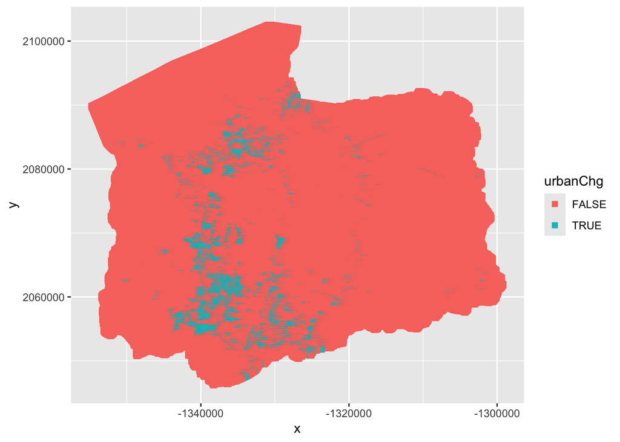

```r
allrastersSL <- allrastersSL %>%
    mutate(urbanChg = (NLCD_2001_SL != 21 & NLCD_2001_SL != 22 & NLCD_2001_SL != 23 & NLCD_2001_SL != 24) &  (NLCD_2016_SL == 21 | NLCD_2016_SL == 22  | NLCD_2016_SL == 23 | NLCD_2016_SL == 24))

ggplot(allrastersSL, aes(y=y, x=x, color=urbanChg)) +
   geom_point(size=2, shape=15) +
   theme()
```

### Create sample for fitting models

For our analysis, we will take a random sample of our entire dataset by grabbing twice as many nondeveloped area cells as urban cells in urbanChg.

```r
SL <- allrastersSL %>%
  filter(NLCD_2001_SL != 21 & NLCD_2001_SL != 22 & NLCD_2001_SL != 23 & NLCD_2001_SL != 24)
SL <- SL[10:14]

#Grab all the developed cells (presence)
newUrban <- SL %>%
  filter(urbanChg == TRUE)

#Grab all the nondeveloped and not previously urban cells (absence)
nonUrban <- SL %>%
  filter(urbanChg == FALSE)

#Get a random sample of the absence data
index <- sample(1:nrow(nonUrban), (round(nrow(newUrban)* 2)))
SLsampleUrban <- nonUrban[index, ]

#Combine the orginal presence and absence data
SLsample <- rbind(SLsampleUrban, newUrban)
SLsample$urbanChg <- as.factor(SLsample$urbanChg)

# Add ID for train/test split
SLsample$id <- 1:nrow(SLsample)

#Create training set
train <- SLsample %>% sample_frac(.70)
#Create test set
test  <- anti_join(SLsample, train, by = 'id')
```

### Fit two models (GLM and Random Forest) based on training sample

```r
gfit <- glm(urbanChg ~ Parks_dist_SL + Rd_dns1km_SL + WaterDist_SL + DEM_SL, data = train,family=binomial())

rfit <- randomForest(
  urbanChg ~ Parks_dist_SL + Rd_dns1km_SL + WaterDist_SL + DEM_SL, data = train, ntree = 500,importance = TRUE)
```

### Get predictions from both models

```r
gpred <- prediction(predict(gfit, test), test$urbanChg)

rprob <- predict(rfit, test, type = "prob")
rpred <- prediction(rprob[, "TRUE"], test$urbanChg)
```

### Compare ROC curve and AUC

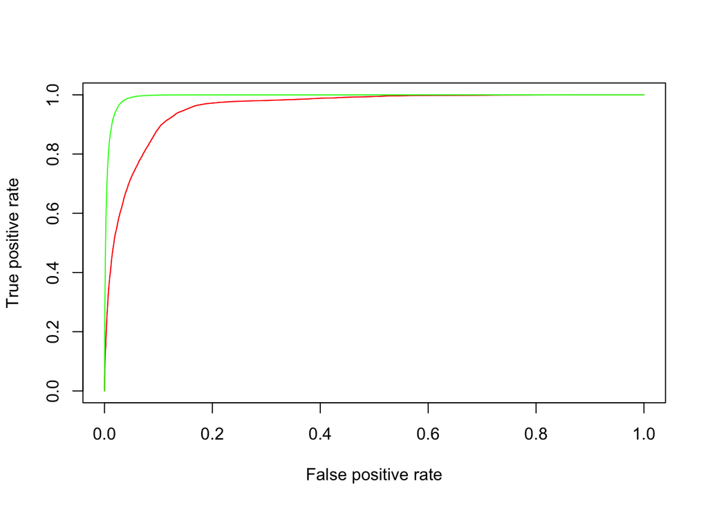

```r
gperf <- performance(gpred, "tpr", "fpr")
rperf <- performance(rpred, "tpr", "fpr")

plot(gperf, col= "red")
plot(rperf, col = "green", add = TRUE)
```

```r
performance(gpred, "auc")@y.values[[1]]
```

```
## [1] 0.9559108
```

```r
performance(rpred, "auc")@y.values[[1]]
```

```
## [1] 0.9946101
```

### Use both models to predict likely locations of development

```r
gpredicted <- predict(allrasters, gfit)
```

```
## |---------|---------|---------|---------|=========================================
```

```r
rpredicted <- predict(allrasters, rfit)
```

```
## |---------|---------|---------|---------|=========================================
```

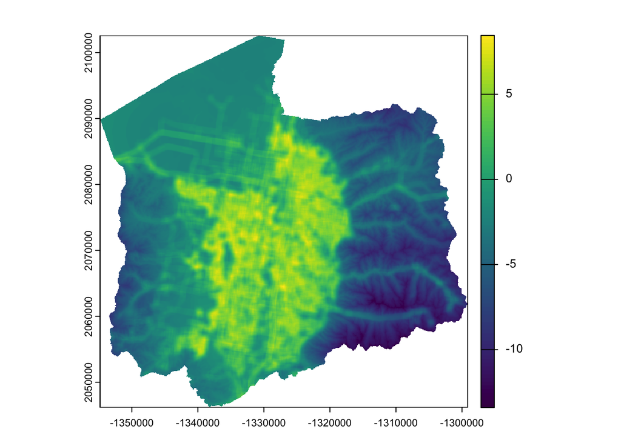

```r
plot(gpredicted)
```

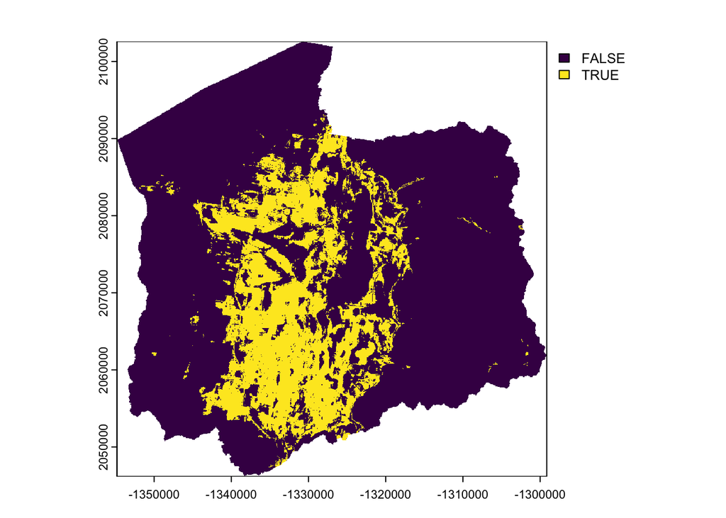

```r
plot(rpredicted)
```

### Understanding Variable Importance

```r
summary(gfit)
```

```
##
## Call:
## glm(formula = urbanChg ~ Parks_dist_SL + Rd_dns1km_SL + WaterDist_SL +
##     DEM_SL, family = binomial(), data = train)
##
## Coefficients:
##                 Estimate Std. Error z value Pr(>|z|)
## (Intercept)    4.281e+00  6.814e-02   62.83   <2e-16 ***
## Parks_dist_SL  1.050e-04  1.609e-06   65.22   <2e-16 ***
## Rd_dns1km_SL   2.108e+01  1.175e-01  179.37   <2e-16 ***
## WaterDist_SL   1.961e-04  8.485e-06   23.11   <2e-16 ***
## DEM_SL        -5.186e-03  5.142e-05 -100.87   <2e-16 ***
## ---
## Signif. codes:  0 '***' 0.001 '**' 0.01 '*' 0.05 '.' 0.1 ' ' 1
##
## (Dispersion parameter for binomial family taken to be 1)
##
##     Null deviance: 280791  on 220709  degrees of freedom
## Residual deviance: 115596  on 220705  degrees of freedom
## AIC: 115606
##
## Number of Fisher Scoring iterations: 7
```

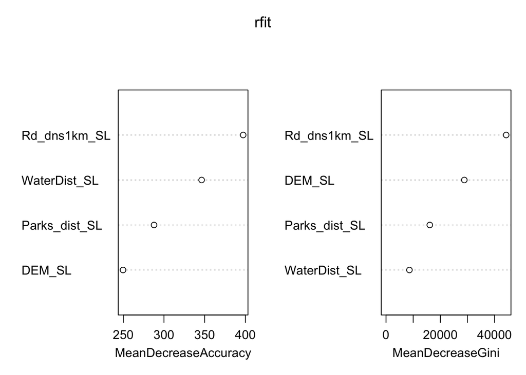

```r
varImpPlot(rfit)
```

### Results and Observations

*1. Analyze the Salt Lake City dataset. Fit a model that explains suitability for urban development (provide evidence of goodness of model fit). What characteristics contribute to urban development in Salt Lake? What variable might you add to better explain urban development. (1-2 paragraphs)*

I fit two models to understand the suitability for urban development in Salt Lake City. GLM is a good model to run because it offers interpretable coefficients that directly show how each variable increases or decreases the likelihood of urban development. Its statistical significance tests help identify which predictors meaningfully contribute to suitability patterns. Random Forest is a well-suited model because it captures complex, nonlinear relationships without making assumptions about data distribution. It also provides good variable importance measures which help identify the strongest drivers of urban development.

From the two models ROC curves and AUC, we can see both models are very well-fit but Random Forest is even better at predicting between urban and nonurban development. From the summary of GLM, we can see high road density has the largest positive effect on urban development, low elevation is the second most influential, and distance to parks and water being the least influential based on the coefficients. Since all of them are highly significant p-values, there is no difference there. From the Random Forest variable importance plot, we can see road density is the most influential with the highest mean decrease accuracy (prediction accuracy) and mean decrease gini (classification). However, the distance to parks and water is the second most influential variable in random forest unlike GLM. A few variables I might add to better explain urban development are more infrastructure factors similar to road density like highway distance, transit station proximity, or distance to commercial centers like Costco or Meijers.

## Cluster Analysis of Amenity Characteristics in the USA

### Load Libraries and Data

```r
library(fastcluster)
```

```r
library(graphics)
library(ggplot2)
library(ggdendro)
library(sf)
amenData<- st_read("AmenDataAll.shp")
colnames(amenData) # know the amenities
```

```
##   [1] "GRIDCODE_1" "ZooAmusSAL" "ZooAmusEMP" "ShopTOT"    "ShopTOTsho"
##   [6] "HotelTOT"   "HotelSALEV" "HotelEMPL"  "HosptTOT"   "HosptEMP"
##  [11] "HighE_TOT"  "HighE_EMP"  "GolfTOT"    "GolfSALEV"  "GolfEMP"
##  [16] "All_Pano"   "Natr_Pano"  "All_Flickr" "Nat_Flickr" "Agri2011"
##  [21] "Agri2001"   "Frst2001"   "Urb2001"    "Agri2006"   "Frst2006"
##  [26] "Urb2006"    "serhouse00" "serhouse10" "Frst2011"   "Urb2011"
##  [31] "serPop90"   "serPop00"   "serPop10"   "secPop65pc" "SecSeas00"
##  [36] "secHiSPl00" "ser00publi" "PanoNature" "WaterPct"   "cstdstL"
##  [41] "distcoast"  "FlickrNatu" "serhous90"  "DEM_min"    "DEM_max"
##  [46] "DEM_range"  "DEM_mean"   "DEM_Variet" "CropVariet" "HikeLength"
##  [51] "ecoZone"    "Landmark"   "HistStruc"  "HistObject" "Histdistr"
##  [56] "Histbuild"  "HistSite"   "Wd_wetland" "Emg_wetld"  "Beach"
##  [61] "barren"     "Grassland"  "Shrubland"  "housingChg" "PopChg"
##  [66] "coast"      "settlment"  "Hist"       "park"       "density"
##  [71] "forestGrou" "agriGroups" "wetlandGro" "GrasslandG" "barrenGrou"
##  [76] "ShrublandG" "ZooEmp"     "ZooCount"   "ZooDist"    "ZooDistEmp"
##  [81] "ShopCount"  "ShopGLATot" "DistGLA"    "DistanceSh" "HotelCount"
##  [86] "HotelEmp"   "HotelDistE" "HotelDist"  "HospitalCo" "HospitalEm"
##  [91] "Hospital_D" "Hospital_1" "HistMonCou" "HistMonEmp" "HistMon_Di"
##  [96] "HistMonume" "HigherEdCo" "HigherEdEm" "HigherEdDi" "HigherEd_1"
## [101] "GolfCount"  "GolfEmpNum" "GolfDistEm" "GolfDist"   "ZPanoNatur"
## [106] "ZFlickrNat" "ZDEM_range" "ZhousingCh" "ZPopChg"    "Zpredicts"
## [111] "ZZooEmp"    "ZZooCount"  "ZZooDist"   "ZZooDistEm" "ZShopCount"
## [116] "ZShopGLATo" "ZDistGLA"   "ZDistanceS" "ZHotelCoun" "ZHotelEmp"
## [121] "ZHotelDist" "ZHotelDi_1" "ZHospitalC" "ZHospitalE" "ZHospital_"
## [126] "ZHospital1" "ZHistMonCo" "ZHistMonEm" "ZHistMon_D" "ZHistMonum"
## [131] "ZHigherEdC" "ZHigherEdE" "ZHigherEdD" "ZHigherEd_" "ZGolfCount"
## [136] "ZGolfEmpNu" "ZGolfDistE" "ZGolfDist"  "geometry"
```

```r
st_geometry(amenData)
```

```
## Geometry set for 79971 features
## Geometry type: POLYGON
## Dimension:     XY
## Bounding box:  xmin: -2356114 ymin: 272043.6 xmax: 2263886 ymax: 3182044
## Projected CRS: NAD83 / Conus Albers
## First 5 geometries:
```

```
## POLYGON ((-1976114 3162044, -1986114 3162044, -...
```

```
## POLYGON ((-1966114 3162044, -1976114 3162044, -...
```

```
## POLYGON ((-1956114 3162044, -1966114 3162044, -...
```

```
## POLYGON ((-1946114 3162044, -1956114 3162044, -...
```

```
## POLYGON ((-1936114 3162044, -1946114 3162044, -...
```

```r
geomData = st_sfc(amenData$geometry) # save spatial attributes of data
```

### Data Cleaning and Transformations

I am choosing to look at the total hotel sales, percentage of water bodies, forest cover in 2011, and total nature pictures taken variables. The reason I chose these variables is to understand the relationships between elements of ecotourism to see if the presence of forests and water bodies has a relationship with where tourists staying at hotels and taking nature pictures would be. My hypothesis is the toursim hotspots will be prominent in a cluster map with these other variables.

```r
amenData$HotelEmpDist_log <- log(amenData$HotelDistE + 0.00000001)
amenDataDF<-amenData[,c("HotelSALEV","WaterPct", "Frst2011", "Nat_Flickr")]

amenDataDF <- na.omit(amenDataDF)
amenDataDF <- as.data.frame(amenDataDF)[1:4]
## calculate z-scores for the dataset
db_scaled <- scale(amenDataDF)
```

### Determine number of clusters for K-mean clustering

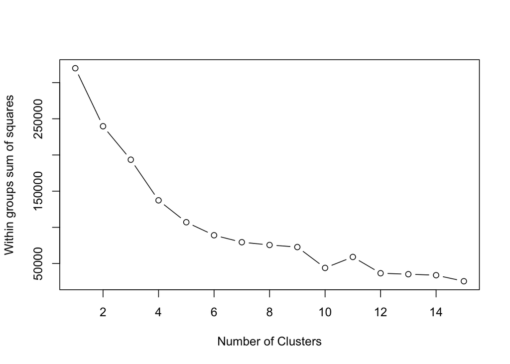

```r
wss <- (nrow(db_scaled)-1)*sum(apply(db_scaled,2,var))
for (i in 2:15) wss[i] <- sum(kmeans(db_scaled,
   centers=i)$withinss)
plot(1:15, wss, type="b", xlab="Number of Clusters",
  ylab="Within groups sum of squares")
```

Based on the elbow graph, the best number of clusters to do is four.

### K-means clustering

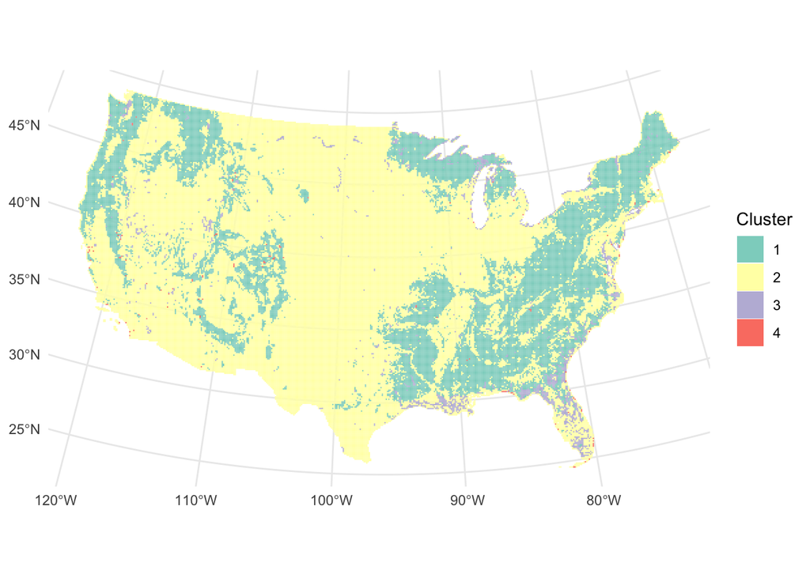

```r
# Perform k-means clustering
fit <- kmeans(db_scaled, 4)

# Append cluster assignment
amenData$cluster <- fit$cluster

# Add geometry back if needed
st_geometry(amenData) <- geomData

# Calculate centroids for each cluster for annotation
centroids <- amenData %>%
  group_by(cluster) %>%
  summarize(geometry = st_centroid(st_union(geometry)))  # union then centroid

# Plot clusters with annotations
ggplot(amenData) +
  geom_sf(aes(fill = as.factor(cluster)), color = NA) +
  scale_fill_brewer(palette = "Set3") +
  theme_minimal() +
  theme(legend.position = "right") +
  labs(fill = "Cluster")
```

### Understanding the variables that are clustered

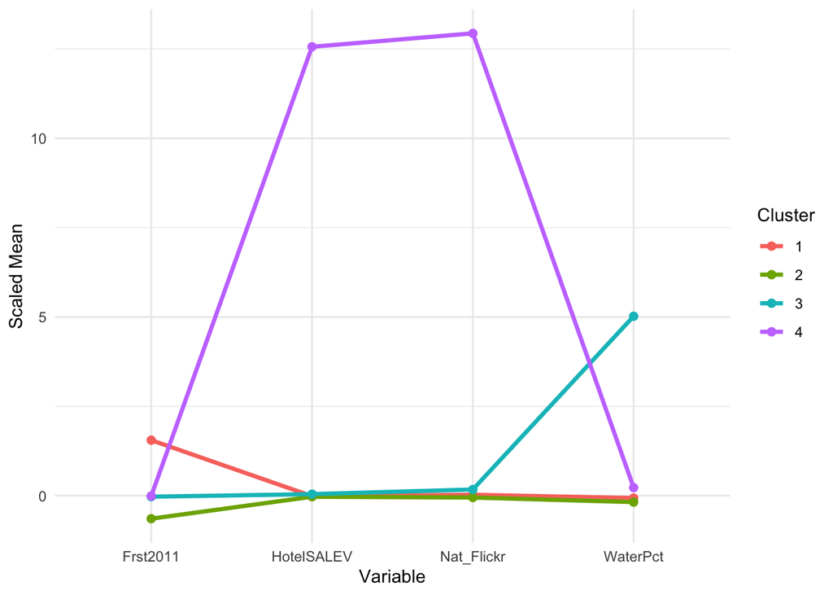

```r
cluster_means <- aggregate(db_scaled, by = list(Cluster = fit$cluster), FUN = mean)
cluster_means_long <- pivot_longer(cluster_means, cols = -Cluster, names_to = "Variable",
  values_to = "Mean")

ggplot(cluster_means_long, aes(x = Variable, y = Mean, group = factor(Cluster), color = factor(Cluster))) +
  geom_line(size = 1.2) +
  geom_point(size = 2) +
  theme_minimal() +
  labs(color = "Cluster", y = "Scaled Mean", x = "Variable")
```

### Results and Observations

*Analyze the database of amenity landscape characteristics using a clustering technique. Choose variables based on a thematic inquiry of your choice. Visualize ad provide qualitative descriptions of the groups that you derive from the clustering techniques. Provide evidence of you characterizations. Provide a map of your cluster analysis. Give an explanation of the spatial distribution of these groups. (1-2 paragraphs)*